# Naive Forecasting Methods

ECON 707/807: Econometrics II - Week 2

Rex Sitti

Old Dominion University - Strome College of Business

## Learning Objectives

By the end of this lecture, you will be able to:

1. Define point forecasts and forecast distributions
2. Understand and apply loss functions (absolute and quadratic)
3. Derive optimal forecasts by minimizing expected loss (risk)
4. Construct forecast intervals for predictions
5. Distinguish between forecast errors and residuals
6. Implement naive forecast methods in R
7. Evaluate when simple forecasts are appropriate

**Note**

**Today’s focus**: The simplest forecasting methods that serve as benchmarks

# Motivating Example

## International Air Passengers Dataset

```r
# Load the classic Air Passengers dataset
data("AirPassengers")
air <- AirPassengers
range(air)  # 1949-1960
```

```
[1] 104 622
```

**Questions to consider:**

1. What would be a good forecast for future passenger counts?
2. How do we define “good”?
3. What is our objective or goal in forecasting?

## Visualizing the Data

Does looking at the distribution change your forecast?

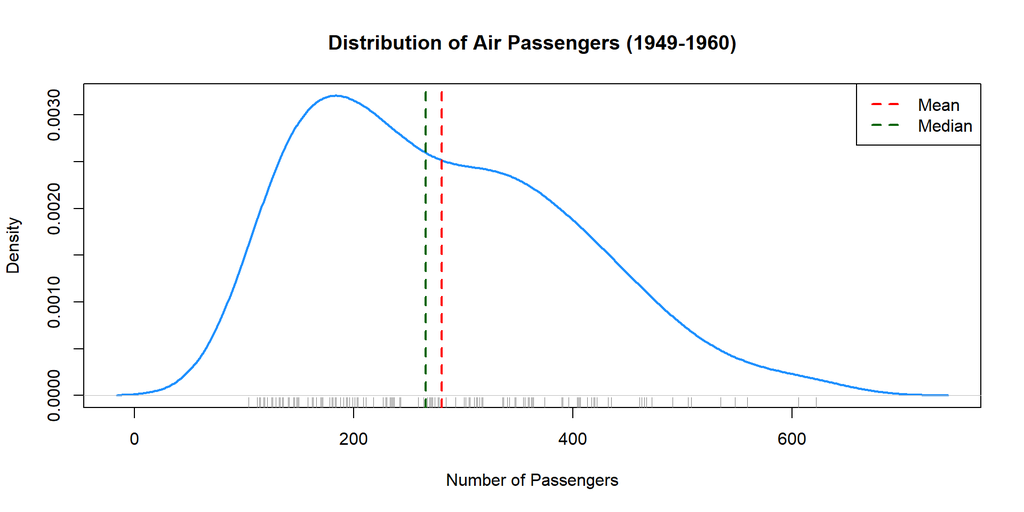

Distribution of monthly air passenger counts

```r
plot(density(air),
     xlab = "Number of Passengers",
     ylab = "Density",
     main = "Distribution of Air Passengers (1949-1960)",
     lwd = 2, col = "dodgerblue")
rug(air, col = "gray50")
abline(v = mean(air), col = "red", lwd = 2, lty = 2)
abline(v = median(air), col = "darkgreen", lwd = 2, lty = 2)
legend("topright",
       legend = c("Mean", "Median"),
       col = c("red", "darkgreen"),
       lty = 2, lwd = 2)
```

## Types of Forecasts

**Point Forecast ($\hat{Y}$)**: A single “best guess” for an unknown future value

**Forecast Distribution**: Complete distribution of possibilities with their probabilities - Captures uncertainty - Provides range of outcomes - More informative than point forecast alone

**Point Forecast (reconsidered)**: A summary statistic of the forecast distribution - Mean, median, mode? - How do we choose? - Enter: **Loss Functions**

**Important**

The choice of summary statistic depends on your loss function!

# Loss Functions and Risk

## Forecast Error

**Forecast error** is the difference between actual and predicted:

$$e = y - \hat{y}$$

**Will there always be forecast error?**

**Answer**: Yes, unless $y$ is deterministic (which it rarely is in economics)!

However, some errors are worse than others. We need a way to evaluate them:

$$L(e): \text{Loss Function}$$

A loss function quantifies how “bad” a forecast error is.

## Common Loss Functions

**Absolute Loss** (L1 loss)
$$L(e) = |e| = |y - \hat{y}|$$

- Linear penalty
- Treats over- and under-forecasts symmetrically
- Robust to outliers
- **Optimal forecast**: Median

**Quadratic Loss** (L2 loss, MSE)
$$L(e) = e^2 = (y - \hat{y})^2$$

- Penalty increases with square of error
- Heavily penalizes large errors
- Differentiable (nice mathematical properties)
- **Optimal forecast**: Mean

**Tip**

Different loss functions lead to different optimal forecasts!

## Risk Minimization

Forecasts seek to minimize **risk**, defined as expected loss:

$$R(\hat{y}) = E[L(e)] = E[L(y - \hat{y})]$$

**For quadratic loss**, let’s find the optimal $\hat{y}$:

$$R(\hat{y}) = E[(y - \hat{y})^2]$$

Expand the squared term:
$$E[(y - \hat{y})^2] = E[y^2 - 2y\hat{y} + \hat{y}^2]$$
$$= E[y^2] - 2\hat{y}E[y] + \hat{y}^2$$

Take derivative with respect to $\hat{y}$ and set to zero:
$$\frac{\partial R}{\partial \hat{y}} = -2E[y] + 2\hat{y} = 0$$

**Solution**:
$$\boxed{\hat{y}^* = E[y]}$$

Under quadratic loss, the **mean** minimizes risk!

## Computing Expectations

How do we calculate $E[y]$ in practice?

**Continuous random variable**:
$$E[Y] = \int_{-\infty}^{\infty} y \cdot f(y) \, dy$$
where $f(y)$ is the probability density function

**Discrete random variable**:
$$E[Y] = \sum_{i} y_i \cdot P(y_i)$$
where $P(y_i)$ is the probability mass function

**Empirical (sample) estimate**:
$$\hat{E}[Y] = \bar{y} = \frac{1}{n}\sum_{i=1}^{n} y_i$$

This is what we use with real data!

## Example: Weighted Coin Flip

Suppose you flip a weighted coin with probabilities:

$$P(\text{Tails}) = \frac{3}{7}, \quad P(\text{Heads}) = \frac{4}{7}$$

**Payoffs:** - Tails: You win $40 - Heads: You lose $25

**Expected value**:
$$E[\text{payoff}] = 40 \cdot \frac{3}{7} + (-25) \cdot \frac{4}{7}$$
$$= \frac{120}{7} - \frac{100}{7} = \frac{20}{7} \approx \$2.86$$

## Applying to Air Passengers

Let’s use our optimal forecast $\hat{y} = E[y]$ (the mean):

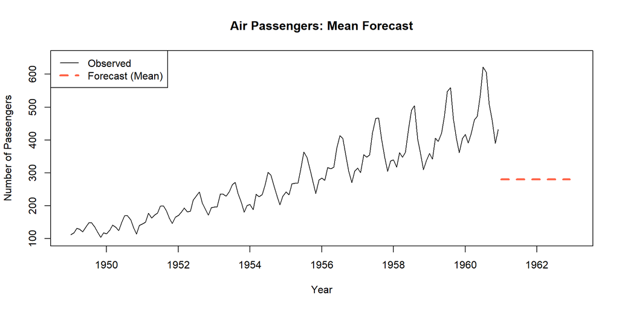

Naive mean forecast for air passengers

```r
# Calculate mean of historical data
mean_forecast <- mean(air)

# Create forecast for 1961-1962
plot(air, xlim = c(1949, 1963), ylim = c(100, 650),
     xlab = "Year", ylab = "Number of Passengers",
     main = "Air Passengers: Mean Forecast")

# Add forecast line
air_forecast <- ts(rep(mean_forecast, 24),
                   start = c(1961, 1),
                   end = c(1962, 12),
                   frequency = 12)
lines(air_forecast, col = "tomato", lwd = 3, lty = 2)
legend("topleft",
       legend = c("Observed", "Forecast (Mean)"),
       col = c("black", "tomato"),
       lty = c(1, 2), lwd = c(1, 3))
```

**Observation**: This looks terrible! Why? (Hint: trend, seasonality)

# Forecast Intervals

## Constructing Confidence Intervals

If $y$ is normally distributed, we can construct a forecast interval:

**General form** (for confidence level $1-\alpha$):
$$\left[\hat{y} - z_{\alpha/2}\sigma, \quad \hat{y} + z_{\alpha/2}\sigma\right]$$

where $z_{\alpha/2}$ is the critical value from the standard normal distribution.

**For 95% confidence** ($\alpha = 0.05$, $z_{0.025} = 1.96$):
$$\left[\hat{y} - 1.96\sigma, \quad \hat{y} + 1.96\sigma\right]$$

**For air passengers**:

```r
mean_air <- round(mean(air), 1)
sd_air <- round(sd(air), 1)
```

$$\left[280.3 - 1.96 \times 120, \quad 280.3 + 1.96 \times 120\right]$$
$$= \left[45.1, \quad 515.5\right]$$

## Visualizing Forecast Intervals

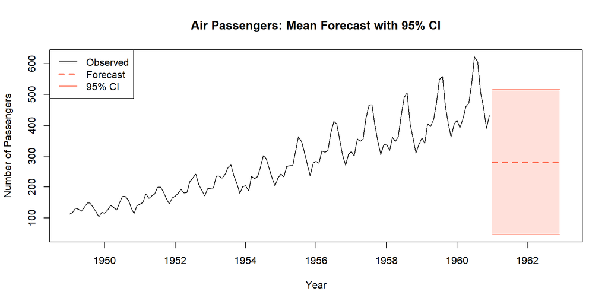

Mean forecast with 95% confidence interval

```r
# Create forecast and intervals
air_forecast <- ts(rep(mean(air), 24),
                   start = c(1961, 1), frequency = 12)
air_upper <- air_forecast + 1.96*sd(air)
air_lower <- air_forecast - 1.96*sd(air)

# Plot
plot(air, xlim = c(1949, 1963),
     ylim = c(min(air, air_lower), max(air, air_upper)),
     xlab = "Year", ylab = "Number of Passengers",
     main = "Air Passengers: Mean Forecast with 95% CI")
lines(air_forecast, col = "tomato", lwd = 2, lty = 2)
lines(air_upper, col = "tomato", lty = 1)
lines(air_lower, col = "tomato", lty = 1)
polygon(c(time(air_forecast), rev(time(air_forecast))),
        c(air_lower, rev(air_upper)),
        col = scales::alpha("tomato", 0.2), border = NA)
legend("topleft",
       legend = c("Observed", "Forecast", "95% CI"),
       col = c("black", "tomato", "tomato"),
       lty = c(1, 2, 1), lwd = c(1, 2, 1))
```

## Implementation in R

```r
# Step 1: Create time index
library(lubridate)
start_date <- ymd("1949-01-01")
end_date <- ymd("1962-12-01")
dates <- seq(start_date, end_date, by = "month")

# Step 2: Create data frame with actual and forecast periods
air_df <- data.frame(
  time = dates,
  air = c(as.numeric(air), rep(NA, 24))  # 24 months of forecast
)

# Step 3: Fit model (just intercept = mean)
model <- lm(air ~ 1, data = air_df)

# Step 4: Generate predictions
air_df$pred <- predict(model, newdata = air_df)

# Step 5: Add confidence intervals
air_df$pred_lower <- air_df$pred - 1.96*sd(air_df$air, na.rm = TRUE)
air_df$pred_upper <- air_df$pred + 1.96*sd(air_df$air, na.rm = TRUE)
```

## Plotting with Base R

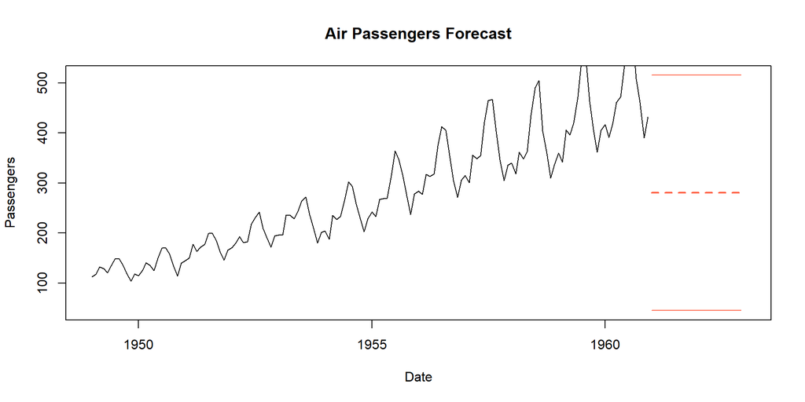

Forecast using data frame approach

```r
# Create the data
library(lubridate)
dates <- seq(ymd("1949-01-01"), ymd("1962-12-01"), by = "month")
air_df <- data.frame(
  time = dates,
  air = c(as.numeric(air), rep(NA, 24))
)

# Fit and predict
model <- lm(air ~ 1, data = air_df)
air_df$pred <- predict(model, newdata = air_df)
air_df$pred_lower <- air_df$pred - 1.96*sd(air_df$air, na.rm = TRUE)
air_df$pred_upper <- air_df$pred + 1.96*sd(air_df$air, na.rm = TRUE)

# Plot
plot(air_df$time, air_df$air,
     xlim = ymd(c("1949-01-01", "1963-01-01")),
     ylim = c(min(air_df$pred_lower, na.rm = TRUE),
              max(air_df$pred_upper, na.rm = TRUE)),
     type = "l", xlab = "Date", ylab = "Passengers",
     main = "Air Passengers Forecast")

# Add forecast region
is_forecast <- air_df$time >= ymd("1961-01-01")
lines(air_df$time[is_forecast], air_df$pred[is_forecast],
      col = "tomato", lty = 2, lwd = 2)
lines(air_df$time[is_forecast], air_df$pred_lower[is_forecast],
      col = "tomato")
lines(air_df$time[is_forecast], air_df$pred_upper[is_forecast],
      col = "tomato")
```

# Time Series Notation

## Cross-Section vs. Time Series vs. Panel

**Cross-Section**

- Subscript: $i$ (iterator)
- Examples: $Y_i$, $X_i$
- One snapshot in time
- Multiple entities

**Time Series**

- Subscript: $t$ (time)
- Examples: $Y_t$, $X_t$
- One entity
- Multiple time periods

**Panel Data**

- Subscripts: $i$ and $t$
- Examples: $Y_{it}$, $X_{it}$
- Multiple entities
- Multiple time periods

**Note**

Today we focus on **time series** data (one entity over time)

## Frequency and Periodicity

**Frequency** refers to the time interval between observations:

| Frequency | Example Data | Observations/Year |
| --- | --- | --- |
| Annual | GDP by year | 1 |
| Quarterly | GDP by quarter | 4 |
| Monthly | Unemployment rate | 12 |
| Weekly | Stock prices | ~52 |
| Daily | Temperature | 365 |
| High-frequency | Stock trades | Thousands+ |

**In R**:

```r
# Monthly data starting January 1949
ts(data, start = c(1949, 1), frequency = 12)

# Quarterly data starting Q1 1990
ts(data, start = c(1990, 1), frequency = 4)
```

## Lags and Leads

**Intertemporal dependency** is a key feature of time series:

**Lags** (past values):
$$y_{t-1}, \quad y_{t-2}, \quad y_{t-k}$$

- $y_{t-1}$: one period ago (yesterday, last month, last year)
- $y_{t-k}$: $k$ periods ago

**Leads** (future values):
$$y_{t+1}, \quad y_{t+2}, \quad y_{t+k}$$

- $y_{t+1}$: one period ahead (tomorrow, next month, next year)
- $y_{t+k}$: $k$ periods ahead

**Sample notation**:
$$\text{Sample: } \{y_1, y_2, y_3, \ldots, y_T\}$$

where $T$ is the last observation in our sample.

## Forecast Notation

**Sample period**: Data we have observed
$$\{y_1, y_2, y_3, \ldots, y_T\}$$

**Out-of-sample period**: Data we want to forecast
$$\{y_{T+1}, y_{T+2}, \ldots, y_{T+h}\}$$

where $h$ is the **forecast horizon** (how far ahead we’re forecasting)

**Ambiguous notation** (avoid!): - $\hat{y}_t$: Is this a forecast for period $t$? Made when? - $\hat{y}_{T+h}$: Forecast for period $T+h$, but made when?

**Clear notation** (use this!):
$$\hat{y}_{T+h|T}$$

“Forecast for period $T+h$, made at time $T$ using information available through period $T$”

# Conditional Forecasting

## The Role of Conditioning Information

**Key principles**:

1. Conditioning on **relevant** variables improves forecasts (reduces risk)
2. Both point forecasts and forecast intervals depend on conditioning variables

Let $\Omega_t$ represent **all available information** at time $t$.

Then our forecast becomes:
$$\hat{y}_{T+h|T} = E[y_{T+h} | \Omega_T]$$

**Information set** $\Omega_T$ might include: - Past values of $y$: $y_T, y_{T-1}, y_{T-2}, \ldots$ - Current and past values of other variables: $x_T, x_{T-1}, \ldots$ - Known relationships, economic theory - Institutional knowledge

## Example: Basketball Player Height

- Unconditional
- Conditional on League

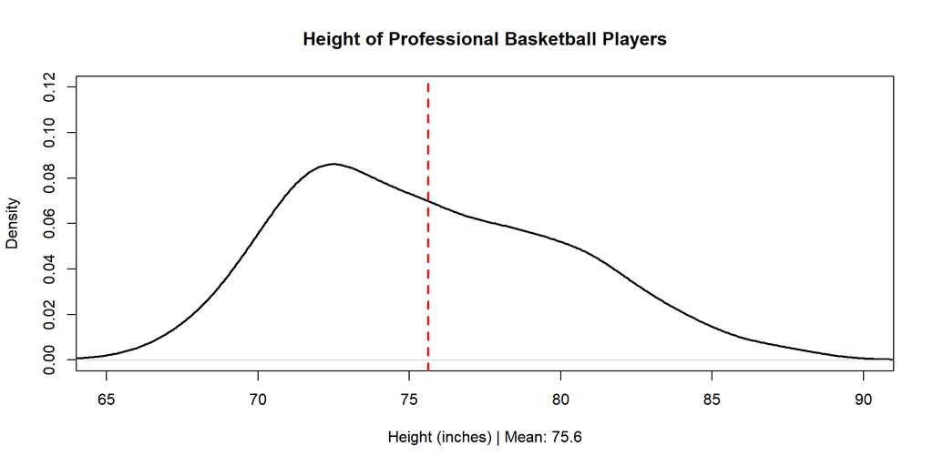

```r
# Simulated data for demonstration
set.seed(707)
nba_height <- rnorm(200, mean = 79, sd = 3.5)
wnba_height <- rnorm(200, mean = 72, sd = 2.5)
heights <- c(nba_height, wnba_height)

plot(density(heights),
     xlim = c(65, 90), ylim = c(0, 0.12),
     main = "Height of Professional Basketball Players",
     xlab = paste("Height (inches) | Mean:", round(mean(heights), 1)),
     lwd = 2)
abline(v = mean(heights), col = "red", lwd = 2, lty = 2)
```

**Unconditional forecast**: $\hat{y} =$ 75.6 inches

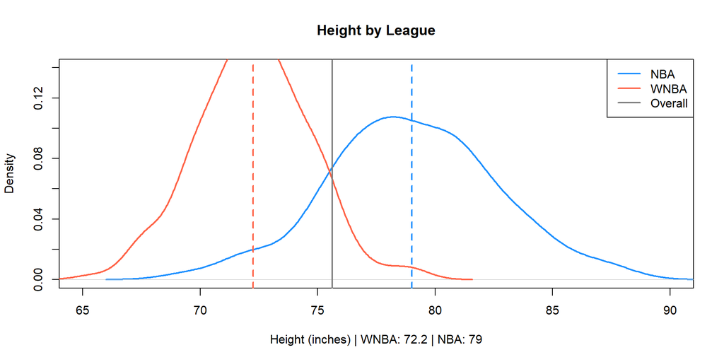

```r
plot(density(nba_height),
     xlim = c(65, 90), ylim = c(0, 0.14),
     main = "Height by League",
     xlab = paste("Height (inches) | WNBA:",
                  round(mean(wnba_height), 1), "| NBA:",
                  round(mean(nba_height), 1)),
     col = "dodgerblue", lwd = 2)
lines(density(wnba_height), col = "tomato", lwd = 2)
abline(v = mean(heights), col = "gray50", lwd = 2, lty = 1)
abline(v = mean(nba_height), col = "dodgerblue", lwd = 2, lty = 2)
abline(v = mean(wnba_height), col = "tomato", lwd = 2, lty = 2)
legend("topright",
       legend = c("NBA", "WNBA", "Overall"),
       col = c("dodgerblue", "tomato", "gray50"),
       lty = c(1, 1, 1), lwd = 2)
```

**Conditional forecasts**: - NBA: 79 inches  
- WNBA: 72.2 inches

**Conditioning matters!** Much more accurate than unconditional mean.

## Relevant vs. Irrelevant Information

**Relevant conditioning**

- NBA vs. WNBA league
- Position played
- Age
- Country of origin

b  Reduces forecast variance

b  Improves accuracy

**Irrelevant conditioning**

- First letter of name
- Jersey number
- Birth month
- Shoe brand

b  Doesn’t help

b  May add noise

**Important**

Not all information is useful! Include only variables that actually predict your outcome.

# Time Series Components

## Decomposing Time Series

We can decompose any time series into components:

$$y_t = \tau_t + C_t + S_t + \epsilon_t$$

where:

| Component | Symbol | Description | Frequency |
| --- | --- | --- | --- |
| **Trend** | $\tau_t$ | Long-term direction | Very long-term, smooth |
| **Cycle** | $C_t$ | Business cycle fluctuations | 2-7 years typically |
| **Seasonal** | $S_t$ | Regular calendar patterns | Annual |
| **Irregular** | $\epsilon_t$ | Random noise | No pattern |

**Tip**

Thinking about components separately (additively) helps us build better models!

## Visualizing Components

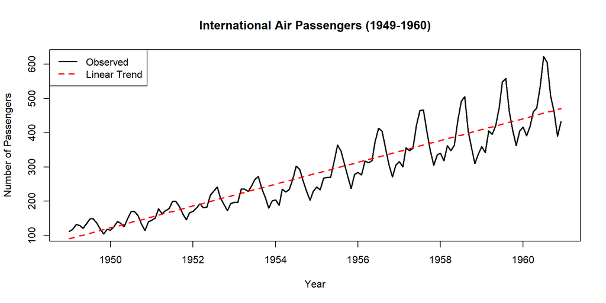

Air passengers showing trend and seasonality

```r
plot(air,
     xlab = "Year",
     ylab = "Number of Passengers",
     main = "International Air Passengers (1949-1960)",
     lwd = 2)

# Add a trend line
time_index <- time(air)
trend_model <- lm(as.numeric(air) ~ time_index)
trend_line <- ts(fitted(trend_model), start = start(air), frequency = 12)
lines(trend_line, col = "red", lwd = 2, lty = 2)

legend("topleft",
       legend = c("Observed", "Linear Trend"),
       col = c("black", "red"),
       lty = c(1, 2), lwd = 2)
```

**What do you see?**

- Clear upward trend
- Regular seasonal pattern
- Increasing variance over time

## When is the Mean Forecast Appropriate?

The simple mean forecast assumes:

$$E[y_{T+h}|\Omega_T] = \beta_0$$

(constant over time, no trend/cycle/season)

**Appropriate when:**

- No trend or seasonality
- Data fluctuate randomly around a constant level
- Stationary process
- Short-term forecasts in stable environments

**NOT appropriate when:**

- Clear trend (like air passengers)
- Seasonal patterns
- Structural breaks
- Long forecast horizons

**Warning**

Always plot your data first! Visual inspection reveals whether mean forecast makes sense.

## Example: Personal Consumption

- Full Sample
- Pre-2020
- Forecasting 2020

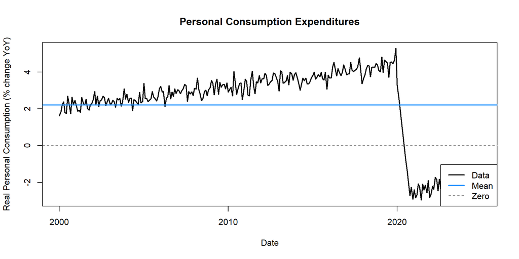

```r
plot(consume_df$DATE, consume_df$PCEC96_PC1,
     type = "l", lwd = 2,
     xlab = "Date",
     ylab = "Real Personal Consumption (% change YoY)",
     main = "Personal Consumption Expenditures")
abline(h = 0, lty = 2, col = "gray50")
abline(h = mean(consume_df$PCEC96_PC1),
       col = "dodgerblue", lwd = 2)
legend("bottomright",
       legend = c("Data", "Mean", "Zero"),
       col = c("black", "dodgerblue", "gray50"),
       lty = c(1, 1, 2), lwd = c(2, 2, 1))
```

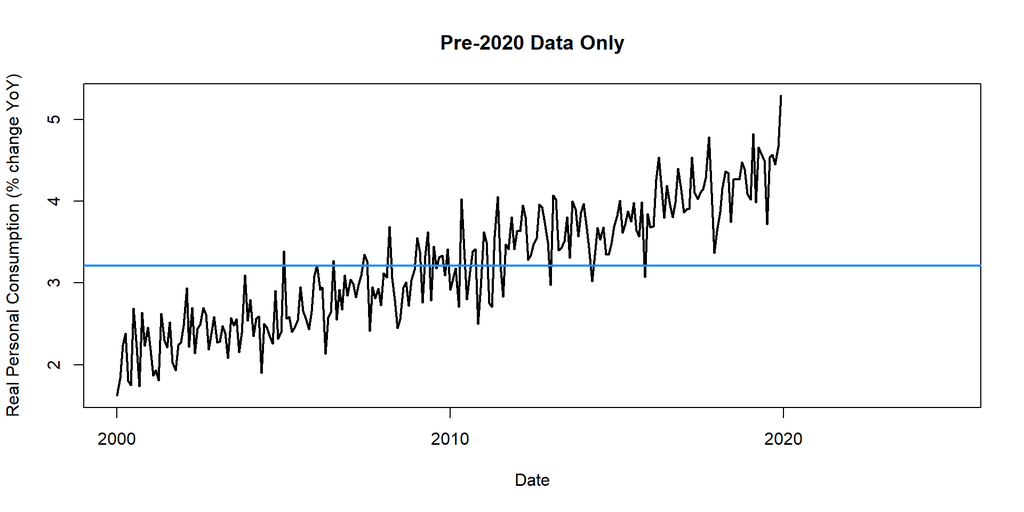

```r
pre_2020 <- consume_df$DATE < ymd("2020-01-01")
plot(consume_df$DATE[pre_2020], consume_df$PCEC96_PC1[pre_2020],
     xlim = range(consume_df$DATE),
     type = "l", lwd = 2,
     xlab = "Date",
     ylab = "Real Personal Consumption (% change YoY)",
     main = "Pre-2020 Data Only")
abline(h = 0, lty = 2, col = "gray50")
abline(h = mean(consume_df$PCEC96_PC1[pre_2020]),
       col = "dodgerblue", lwd = 2)
```

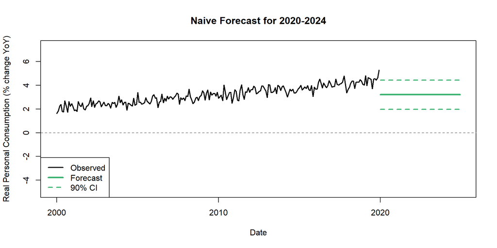

```r
pre_2020_data <- consume_df$PCEC96_PC1[pre_2020]
mean_pre <- mean(pre_2020_data)
sd_pre <- sd(pre_2020_data)

plot(consume_df$DATE[pre_2020], consume_df$PCEC96_PC1[pre_2020],
     xlim = range(consume_df$DATE),
     ylim = range(consume_df$PCEC96_PC1) + c(-2, 2),
     type = "l", lwd = 2,
     xlab = "Date",
     ylab = "Real Personal Consumption (% change YoY)",
     main = "Naive Forecast for 2020-2024")
abline(h = 0, lty = 2, col = "gray50")

# Add forecast
post_2020 <- !pre_2020
segments(x0 = min(consume_df$DATE[post_2020]),
         x1 = max(consume_df$DATE),
         y0 = mean_pre, lwd = 3, col = "mediumseagreen")
segments(x0 = min(consume_df$DATE[post_2020]),
         x1 = max(consume_df$DATE),
         y0 = mean_pre + 1.645*sd_pre,
         lty = 2, lwd = 2, col = "mediumseagreen")
segments(x0 = min(consume_df$DATE[post_2020]),
         x1 = max(consume_df$DATE),
         y0 = mean_pre - 1.645*sd_pre,
         lty = 2, lwd = 2, col = "mediumseagreen")
legend("bottomleft",
       legend = c("Observed", "Forecast", "90% CI"),
       col = c("black", "mediumseagreen", "mediumseagreen"),
       lty = c(1, 1, 2), lwd = c(2, 3, 2))
```

**What happened?** Structural break (COVID-19) makes pre-2020 mean inappropriate!

# Errors vs. Residuals

## Important Distinction

**Forecast Errors** (true errors)

$$e_{T+h} = y_{T+h} - \hat{y}_{T+h|T}$$

- Unknown until future is observed
- What we care about
- Measure forecast accuracy
- Can’t compute until $y_{T+h}$ is known

**Example**: Forecast for 2025 made in 2024 Can’t compute error until 2025!

**Residuals** (in-sample errors)

$$\hat{e}_t = y_t - \hat{y}_t$$

- Computed on observed data
- Training error
- Used for model diagnostics
- Available immediately

**Example**: “Prediction” for 2020 using full dataset including 2020 Not a true forecast!

**Important**

**Residuals b Forecast Errors!** Residuals underestimate true forecast error.

## Why Residuals Matter

Even though residuals aren’t true forecast errors, they’re useful for:

1. **Model diagnostics**
   - Should look like white noise (random)
   - No patterns remaining
   - Check autocorrelation
2. **Estimating forecast uncertainty**
   - Residual standard deviation b forecast interval width
   - Assumes errors similar in-sample and out-of-sample
3. **Model comparison**
   - Lower residual variance often (not always) means better forecasts
   - Need out-of-sample validation to be sure

## Plotting Residuals

```r
# Fit mean model on air passengers
mean_model <- lm(air ~ 1)
residuals <- residuals(mean_model)

par(mfrow = c(1, 2))

# Time series plot of residuals
plot(residuals,
     type = "l",
     ylab = "Residuals",
     xlab = "Time",
     main = "Residuals Over Time")
abline(h = 0, col = "red", lty = 2)

# Histogram of residuals
hist(residuals,
     breaks = 20,
     main = "Distribution of Residuals",
     xlab = "Residual",
     col = "lightblue")
```

```r
par(mfrow = c(1, 1))
```

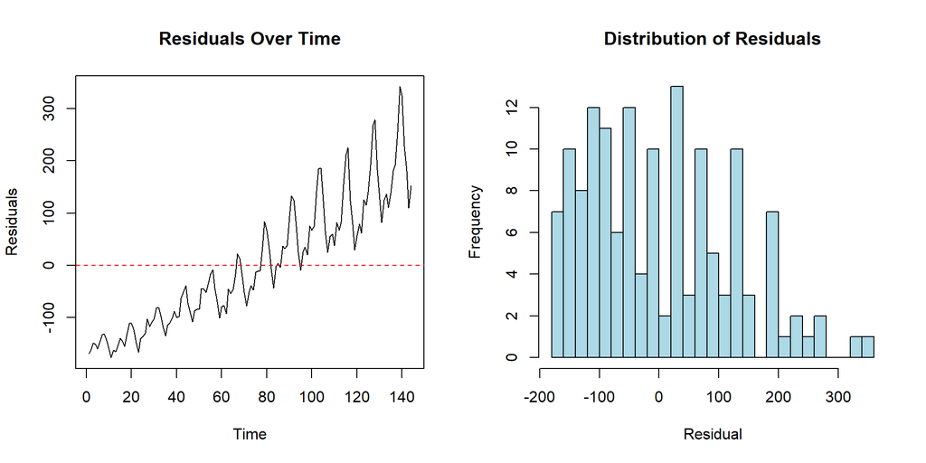

Residual plot for mean forecast

**What do you see?** Clear pattern in residuals b model is missing something (trend/seasonality)!

# Summary and Next Steps

## What We Learned Today

1. **Loss functions** determine optimal forecasts
   - Quadratic loss b mean
   - Absolute loss b median
2. **Risk minimization** provides theoretical foundation for forecasting
3. **Forecast intervals** quantify uncertainty
   - Depend on distribution assumptions
   - Width depends on forecast horizon
4. **Conditioning** on relevant information improves forecasts
5. **Naive forecasts** serve as benchmarks
   - Simple to compute
   - Often hard to beat for short horizons
   - Inappropriate when trends/seasonality present
6. **Time series components**: Trend, Cycle, Season, Irregular
7. **Residuals b Forecast errors** (important distinction!)

## Next Class Preview

**Topics for Week 3**:

1. **Forecast Variance**
   - How uncertainty increases with horizon
   - Role of parameter uncertainty
   - Simulation-based methods
2. **Trend Models**
   - Linear trends: $y_t = \beta_0 + \beta_1 t + \epsilon_t$
   - Polynomial trends
   - Exponential trends
3. **Structural Breaks**
   - Intercept shifts (level changes)
   - Trend breaks (slope changes)
   - Testing for breaks
4. **Forecast Evaluation**
   - Out-of-sample testing
   - Comparing forecast accuracy

# Practice Problems

## Problem 1: Optimal Forecasts

Given the following probability distribution for tomorrow’s stock return:

| Return | Probability |
| --- | --- |
| -10% | 0.2 |
| 0% | 0.5 |
| +15% | 0.3 |

**a)** Calculate the expected return (optimal forecast under quadratic loss)

**b)** What is the optimal forecast under absolute loss?

**c)** Calculate the expected risk (variance) under quadratic loss

**d)** If you forecast +5% instead of the optimal forecast, how much does your expected loss increase?

## Problem 2: Forecast Intervals

Monthly sales have mean $100,000 and standard deviation $20,000.

**a)** Construct a 90% forecast interval (use $z_{0.05} = 1.645$)

**b)** Construct a 95% forecast interval (use $z_{0.025} = 1.96$)

**c)** How does the interval width change from 90% to 95%? Why?

**d)** If sales are actually $85,000, which interval successfully captured the truth?

**e)** If standard deviation increases to $30,000, how does the 95% interval change?

## Problem 3: R Implementation

Download monthly unemployment rate data from FRED (series: UNRATE).

**a)** Split data: use 2000-2019 for training, 2020-2024 for testing

**b)** Compute mean forecast using training data

**c)** Calculate forecast errors for test period

**d)** Compute Mean Absolute Error (MAE) and Root Mean Squared Error (RMSE)

**e)** Create a plot showing: - Historical data - Forecast period with point forecast - 95% forecast interval - Actual test data

**f)** Does the forecast interval contain the actual 2020 recession spike? Discuss.

## Problem 4: Conditioning

Consider forecasting the number of umbrellas sold tomorrow.

**a)** List 3 pieces of information that would likely **improve** your forecast (explain why)

**b)** List 3 pieces of information that would likely **not help** your forecast

**c)** If you condition on weather forecast (rain vs. no rain), how would you construct your forecast differently?

**d)** Suppose historical data shows: - Average sales on rainy days: 50 umbrellas - Average sales on sunny days: 10 umbrellas  
- Probability of rain tomorrow: 60%

What is your unconditional forecast? What if you know it will rain?

## Resources and References

**Textbooks**:

- Hyndman & Athanasopoulos: [*Forecasting: Principles and Practice*](https://otexts.com/fpp3/) Ch. 1-3
- Diebold: *Elements of Forecasting* Ch. 2-3
- Hamilton: *Time Series Analysis* Ch. 1

**R Packages**:

```r
library(forecast)    # Forecasting tools
library(fpp3)        # Data and examples from textbook
library(tsibble)     # Modern time series data structures
```

**Online Resources**:

- [FRED Economic Data](https://fred.stlouisfed.org/)
- [R for Data Science](https://r4ds.had.co.nz/) - Data manipulation
- Course materials on Canvas

## Questions?

**Office Hours**: [TH/FR 2:30-4PM]

**Email**: rsitti@odu.edu

**Next Class**: Trend models and structural breaks

**Homework**

- Complete practice problems
- Read: Hyndman & Athanasopoulos Ch. 3
- Bring questions about your forecasting projects